# Emergency Response Data from the College Park Volunteer Fire Department

[figure not shown]

### **Introduction**

The following project will walk you through the various processes of the Data Science Pipeline by exploring emergency response statistics from 2018 at the College Park Volunteer Fire Department (CPVFD). The CPVFD is located directly across Baltimore Avenue from the University of Maryland Campus and is primarily responsible for serving the entirety of the campus community, along with outside communities, yearround. Many of the live-in volunteers at the station are current students at the University that dedicate their time when not attending classes each day. The following data was obtained from the database system used to log call information after every incident. Some data was omitted for privacy concerns but the removed data portions do not detract from the exploration done in the project. I was able to get this data as I am a current live-in volunteer and manage the call database system that is used.

### **I. Data Collection**

The first step in obtaining the data was to extract the fire responses portion for the year 2018 from the database used at the station. After this was done, the necessary personal data was removed and the fire responses were exported locally as a .csv file.

Now, we can import this data from a .csv to a data frame in R:

```r
fire <- read.csv("D:/Documents/320/Final/Fire_Response.csv")
head(fire)
```

```
##   Incident.Number      Date  Time.Out   Time.In              Location
## 1      1818040001  4-Aug-18 00-Jan-00 00-Jan-00      8125 48th Avenue
## 2      1817300420 31-Dec-18 00-Jan-00 00-Jan-00      4705 Guilford Rd
## 3      1816120010 12-Jun-18 00-Jan-00 00-Jan-00 7400 Baltimore Avenue
## 4      1812310330 31-Dec-18 00-Jan-00 00-Jan-00         8811 34th Ave
## 5      1812310267 31-Dec-18 00-Jan-00 00-Jan-00     4931 calvert road
## 6      1812300287 30-Dec-18 00-Jan-00 00-Jan-00      4705 Guilford rd
##                      Call.Type        Response.Area Company.Run..
## 1             Automatic Alarms     Surrounding Area       1083015
## 2                  EMS Assists City of College Park       1996156
## 3             Automatic Alarms City of College Park        830071
## 4 Hazmat / Hazardous Condition City of College Park       1999159
## 5      Non-Emergency Incidents City of College Park       1998158
## 6 Hazmat / Hazardous Condition City of College Park       1995155
##   Box.or.Street.Assignment Working.Fire Unit.1
## 1                    FALSE        FALSE   E121
## 2                    FALSE        FALSE   E122
## 3                    FALSE        FALSE   E121
## 4                    FALSE        FALSE   E122
## 5                    FALSE        FALSE   E122
## 6                    FALSE        FALSE   E122
```

Using the head command, we can see the first six observations in our data set. Now that we have imported our data, we can move onto the next step of the Data Science Pipeline.

### **II. Data Processing**

Let us take another quick look at our data by pulling up the first 10 observations in our data set:

```r
library(tidyverse)
slice(fire, 1:10)
```

```
##    Incident.Number      Date  Time.Out   Time.In                Location
## 1       1818040001  4-Aug-18 00-Jan-00 00-Jan-00        8125 48th Avenue
## 2       1817300420 31-Dec-18 00-Jan-00 00-Jan-00        4705 Guilford Rd
## 3       1816120010 12-Jun-18 00-Jan-00 00-Jan-00   7400 Baltimore Avenue
## 4       1812310330 31-Dec-18 00-Jan-00 00-Jan-00           8811 34th Ave
## 5       1812310267 31-Dec-18 00-Jan-00 00-Jan-00       4931 calvert road
## 6       1812300287 30-Dec-18 00-Jan-00 00-Jan-00        4705 Guilford rd
## 7       1812300010 30-Dec-18 00-Jan-00 00-Jan-00       6040 Greenbelt Rd
## 8       1812290090 29-Dec-18 00-Jan-00 00-Jan-00 12601 Old Marlboro Pike
## 9       1812280338 28-Dec-18 00-Jan-00 00-Jan-00       8811 Greenbelt rd
## 10      1812270375 28-Dec-18 00-Jan-00 00-Jan-00         8700 Boteler ln
##                       Call.Type          Response.Area Company.Run..
## 1              Automatic Alarms       Surrounding Area       1083015
## 2                   EMS Assists   City of College Park       1996156
## 3              Automatic Alarms   City of College Park        830071
```

[output cut: 18 more lines]

Now we can begin looking at what kind of data we are working with. We see that for each data point, or entinty, that we have, there are 11 attributes. These attributes are “Incident.Number, Date, Time.Out, Time.In, Location, Call.Type, Response.Area, Compant.Run.#, Box.or.Street.Assignment, Working.Fire, and Unit.1”. Now that we’ve listed our attributes, lets break them down a little bit.

Just from these first 10 points, we can start to form an idea of what type of attributes each of the 11 belong to. For example, it looks as though we have three different attributes which are categorical data simply by how they appear in the first 10 entities. These attributes appear to be ‘Call.Type’, ‘Response.Area’ and ‘Unit.1’. To test this theory, we can use the table feature from tidyverse:

```r
table(fire$Call.Type)
```

```
##
##                                                      2327
##                            6                            1
##             Automatic Alarms                  EMS Assists
##                          317                          231
## Hazmat / Hazardous Condition      Non-Emergency Incidents
##                          219                          126
##              Other Emergency                      Rescues
##                           18                          147
##               Structure Fire              Vegetation Fire
##                          349                           28
##                 Vehicle Fire              Water Incidents
##                           11                            1
```

```r
table(fire$Response.Area)
```

```
##
##                          City of College Park       Surrounding Area
##                      9                    619                    573
## University of Maryland
##                    253
```

```r
table(fire$Unit.1)
```

```
##
##             122  Cart12    E121    E122     F12  HMSU12    Stat    TK12 Utility
##      10       1       6     344     640       8      11       3     424       7
```

The above code confirms our suspicions that those three data types were categorical in nature. We can also now see all of the options we had for each category. There seem to be a few glaring mistakes which can be chalked up to user error. So that these mistakes don’t affect our data operations later on, we can use R to filter them out:

```r
fire <- fire %>%
  filter(Call.Type != "") %>%
  filter(Call.Type != "2327") %>%
  filter(Response.Area != "") %>%
  filter(Unit.1 != "")
```

We will also quickly mutate to add an additional column of Month for each entity to be used with later analysis.

```r
fire <- fire %>%
  mutate(Month = str_extract(fire$Date, "[A-Za-z]+"))
head(fire)
```

```
##   Incident.Number      Date  Time.Out   Time.In              Location
## 1      1818040001  4-Aug-18 00-Jan-00 00-Jan-00      8125 48th Avenue
## 2      1817300420 31-Dec-18 00-Jan-00 00-Jan-00      4705 Guilford Rd
## 3      1816120010 12-Jun-18 00-Jan-00 00-Jan-00 7400 Baltimore Avenue
## 4      1812310330 31-Dec-18 00-Jan-00 00-Jan-00         8811 34th Ave
## 5      1812310267 31-Dec-18 00-Jan-00 00-Jan-00     4931 calvert road
## 6      1812300287 30-Dec-18 00-Jan-00 00-Jan-00      4705 Guilford rd
##                      Call.Type        Response.Area Company.Run..
## 1             Automatic Alarms     Surrounding Area       1083015
## 2                  EMS Assists City of College Park       1996156
## 3             Automatic Alarms City of College Park        830071
## 4 Hazmat / Hazardous Condition City of College Park       1999159
## 5      Non-Emergency Incidents City of College Park       1998158
## 6 Hazmat / Hazardous Condition City of College Park       1995155
##   Box.or.Street.Assignment Working.Fire Unit.1 Month
## 1                    FALSE        FALSE   E121   Aug
## 2                    FALSE        FALSE   E122   Dec
## 3                    FALSE        FALSE   E121   Jun
## 4                    FALSE        FALSE   E122   Dec
## 5                    FALSE        FALSE   E122   Dec
## 6                    FALSE        FALSE   E122   Dec
```

Now that we’ve cleaned our data a bit, we can look at the remainder of our attributes. We can see that the “Date” attribute is a Date-Time variable that corresponds to when the call took place. Location seems to be a manually entered address for the dispatched location of each call (or entity). Lastly, ‘Box.or.Street.Assignment’ and ‘Working.Fire’ both appear to be two boolean categorical variables which either confirm or deny they attribute they’re related to.

For some clarification, these two attributes correspond to the call type for certain emergencies as specified in the General Orders for all Prince George’s County emergency responses. These General Orders will be linked below in the resources section, but two of the types of calls defined here are “Street” and “Box”. Along with the type of units dispatched for each of these assignments, they are also dispatched based on what the caller claims the nature of the emergency is when they call 911.

A “Street” assignment is the less emergent of the two and is usually dispatched for emergencies that may require additional manpower but are not completely serious. An example may be odor of gas inside of a caller’s home or a malfunctioning appliance.

A “Box” assignment is the most emergent call type. These are for reports that could potentially be indicative of a serious/major emergency. There are more units assigned to these assignments on dispatch. Some examples may be a caller complaining of smoke or fire inside of their home or building.

So, the variable for ‘Box.or.Street.Assignment’ shows whether or not the call belonged to one of these call types. The ‘Working.Fire’ attribute is designed to show whether or not the call (or entity) was actually on fire or not. Many times, the calls that are responded to for complaints of smoke or fire inside of a home (Box assignments, as discussed earlier) are not as emergent as initially reported. Some cases of this could be if a caller simply burnt the food they were cooking, or if nothing was found upon arrival and further invesitgation. The ‘Working.Fire’ categorical attribute works to show which calls were actual working fire incidents.

The Time.Out and Time.In attributes were added in 2019 for better tracking within the database. That being said, they were never used in the 2018 data so they may be removed.

The remaining two variables, ‘Incident.Number’ and ‘Company.Run.#’ are used for logkeeping outside of the database system. That being said, they don’t have any real bearing on our data analysis, so we can use the select command to omit them from further operations:

```r
fire <- fire%>%select(-Incident.Number, -Company.Run.., -Time.In, -Time.Out)

#Leaving us with the following data frame:
slice(fire, 1:10)
```

```
##         Date                Location                    Call.Type
## 1   4-Aug-18        8125 48th Avenue             Automatic Alarms
## 2  31-Dec-18        4705 Guilford Rd                  EMS Assists
## 3  12-Jun-18   7400 Baltimore Avenue             Automatic Alarms
## 4  31-Dec-18           8811 34th Ave Hazmat / Hazardous Condition
## 5  31-Dec-18       4931 calvert road      Non-Emergency Incidents
## 6  30-Dec-18        4705 Guilford rd Hazmat / Hazardous Condition
## 7  30-Dec-18       6040 Greenbelt Rd Hazmat / Hazardous Condition
## 8  29-Dec-18 12601 Old Marlboro Pike               Structure Fire
## 9  28-Dec-18       8811 Greenbelt rd               Structure Fire
## 10 28-Dec-18         8700 Boteler ln             Automatic Alarms
##             Response.Area Box.or.Street.Assignment Working.Fire Unit.1 Month
## 1        Surrounding Area                    FALSE        FALSE   E121   Aug
## 2    City of College Park                    FALSE        FALSE   E122   Dec
## 3    City of College Park                    FALSE        FALSE   E121   Jun
## 4    City of College Park                    FALSE        FALSE   E122   Dec
## 5    City of College Park                    FALSE        FALSE   E122   Dec
## 6    City of College Park                    FALSE        FALSE   E122   Dec
## 7        Surrounding Area                     TRUE        FALSE   E122   Dec
## 8        Surrounding Area                     TRUE         TRUE   E122   Dec
## 9        Surrounding Area                     TRUE        FALSE   E122   Dec
## 10 University of Maryland                    FALSE        FALSE   E122   Dec
```

The last thing we can do is write a script that uses ggmap to parse latitude and longitude values from the addresses found in the locations attribute. An easy way to do this is to simply create another .csv file with only the location addresses called “addresses.csv”. We then use the following script to generate another .csv called “geocoded.csv” which shows the addresses and their corresponding lat lng values. The script is as follows:

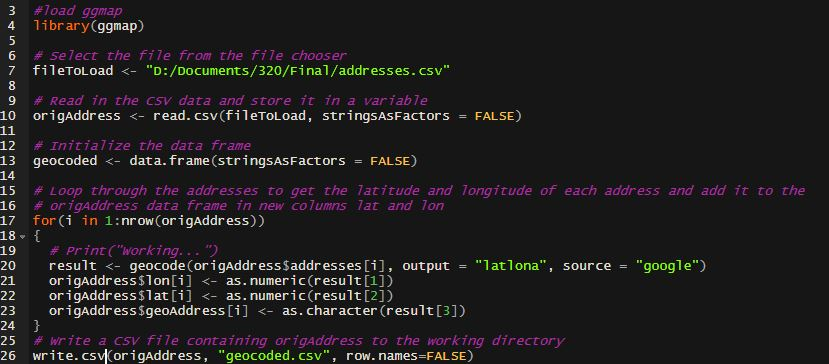

Now that we’ve formatted and processed all of our data for what we need, we may begin to move on to the next section and begin visualizing our data.

### **III. Exploratory Analysis and Data Visualization**

Based on the types of attributes we have, we can begin to visualize certain aspects of our data. The first thing we will look at is calls per month for the year of 2018:

```r
monthly <- table(fire$Month)
monthly <- as.data.frame(monthly)
monthly <- monthly %>% arrange(factor(Var1, c("Jan", "Feb", "Mar", "Apr", "May", "Jun", "Jul", "Aug", "Sep", "Oct", "Nov", "Dec")))
monthly <- monthly %>% rename(Month = Var1, Num_Calls=Freq)
monthly
```

```
##    Month Num_Calls
## 1    Jan       124
## 2    Feb       105
## 3    Mar        96
## 4    Apr       124
## 5    May        94
## 6    Jun       111
## 7    Jul       105
## 8    Aug       107
## 9    Sep       134
## 10   Oct       183
## 11   Nov       134
## 12   Dec       121
```

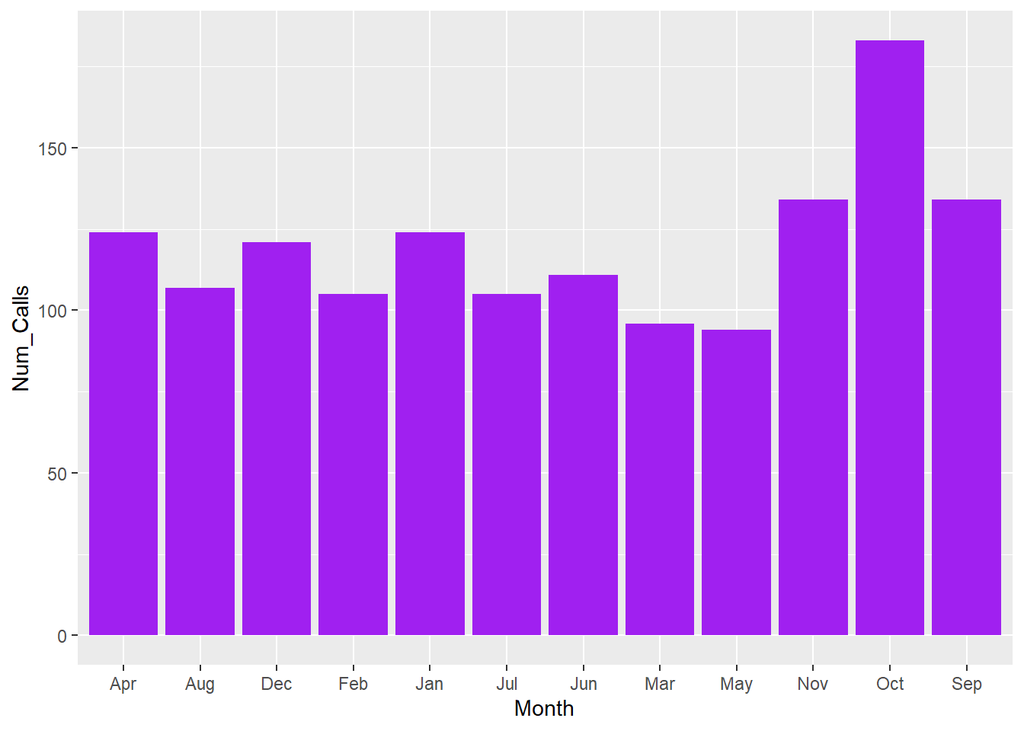

```r
monthly %>% ggplot(mapping = aes(y=Num_Calls, x=Month)) + geom_bar(stat="identity", fill="purple")
```

We can do a similar process for our other categorical variables, ‘Call.Type’, ‘Response.Area’ and ‘Unit.1’:

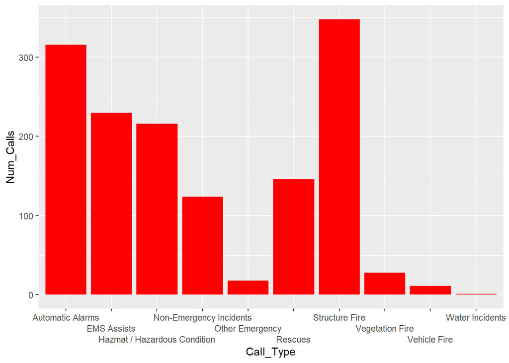

```r
call_type <- table(fire$Call.Type)
call_type <- as.data.frame(call_type)
call_type <- call_type %>% rename(Call_Type = Var1, Num_Calls = Freq)

resp_area <- table(fire$Response.Area)
resp_area <- as.data.frame(resp_area)
resp_area <- resp_area %>% rename(Area = Var1, Num_Calls = Freq)

unit <- table(fire$Unit.1)
unit <- as.data.frame(unit)
unit <- unit %>% rename(Unit = Var1, Num_Calls = Freq)

call_type %>% ggplot(mapping = aes(y=Num_Calls, x=Call_Type)) + geom_bar(stat="identity", fill="red") + scale_x_discrete(guide = guide_axis(n.dodge=3))
```

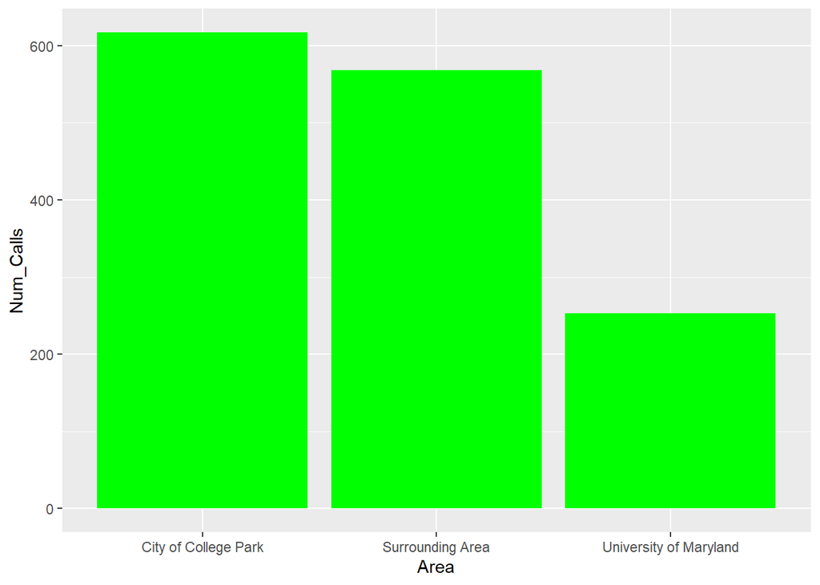

```r
resp_area %>% ggplot(mapping = aes(y=Num_Calls, x=Area)) + geom_bar(stat="identity", fill="green")
```

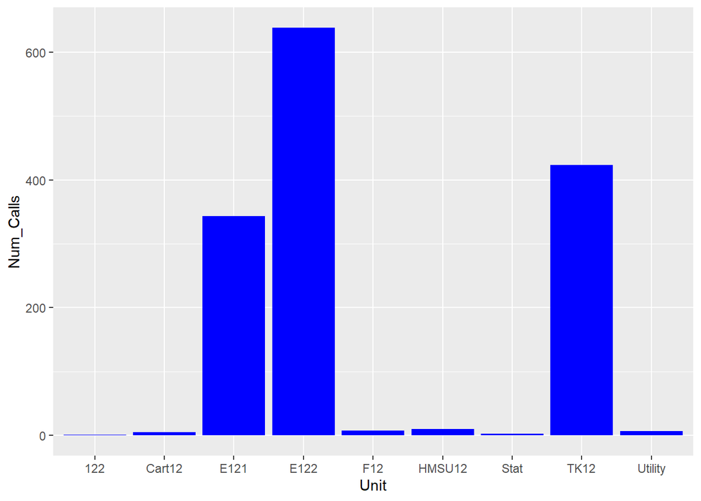

```r
unit %>% ggplot(mapping = aes(y=Num_Calls, x=Unit)) + geom_bar(stat="identity", fill="blue")
```

One final visualization we can do is using the script we wrote earlier to find the apporpriate longitude and latitude variables based on the location attribute:

```r
library(leaflet)
geodata <- read.csv("D:/Documents/320/Final/geocoded.csv")
map <- leaflet(data = geodata) %>% addTiles() %>% addMarkers(lng = geodata$lng, lat = geodata$lat)
map
```

[interactive chart not shown]

### **Insights**

The last big graphic that helps pain a picture of the CPVFD response statistics is the geomap. The points quite literally pain a shape over the city of College Park and surrounding areas, which truly helps show the scale of the station’s response area. There are even outlier points near airports towards the capital where units would be sent on certain circumstances for special occasions, such as standbys for presidential landings.

### **Resources**

1. PGFD General Orders
2. PGFD Stations
3. CPVFD